# Udacity_Project_5

## ${\textbf{Data exploration of store customers and candy bars purchases}}$

The dataset consists of information about the purchases of chocolate candy bars of 500 individuals from a given area when entering a physical ‘FMCG’ store in the period of 2 years. All data has been collected through the loyalty cards they use at checkout. The volume of the dataset has been restricted and anonymised to protect the privacy of the customers.

## ${\textbf{Libraries}}$

```python
# import the necessary libraries
import pandas as pd
import matplotlib.pyplot as plt
import numpy as np
import seaborn as sns
import warnings
warnings.filterwarnings("ignore")
```

## ${\textbf{Data Import}}$

```python
# read the purchase data csv file.
df_purchase = pd.read_csv('purchase data.csv')
```

```python
df_purchase.head()
```

|  | ID | Day | Incidence | Brand | Quantity | Last_Inc_Brand | Last_Inc_Quantity | Price_1 | Price_2 | Price_3 | ... | Promotion_3 | Promotion_4 | Promotion_5 | Sex | Marital status | Age | Education | Income | Occupation | Settlement size |
| --- | --- | --- | --- | --- | --- | --- | --- | --- | --- | --- | --- | --- | --- | --- | --- | --- | --- | --- | --- | --- | --- |
| 0 | 200000001 | 1 | 0 | 0 | 0 | 0 | 0 | 1.59 | 1.87 | 2.01 | ... | 0 | 0 | 0 | 0 | 0 | 47 | 1 | 110866 | 1 | 0 |
| 1 | 200000001 | 11 | 0 | 0 | 0 | 0 | 0 | 1.51 | 1.89 | 1.99 | ... | 0 | 0 | 0 | 0 | 0 | 47 | 1 | 110866 | 1 | 0 |
| 2 | 200000001 | 12 | 0 | 0 | 0 | 0 | 0 | 1.51 | 1.89 | 1.99 | ... | 0 | 0 | 0 | 0 | 0 | 47 | 1 | 110866 | 1 | 0 |
| 3 | 200000001 | 16 | 0 | 0 | 0 | 0 | 0 | 1.52 | 1.89 | 1.98 | ... | 0 | 0 | 0 | 0 | 0 | 47 | 1 | 110866 | 1 | 0 |
| 4 | 200000001 | 18 | 0 | 0 | 0 | 0 | 0 | 1.52 | 1.89 | 1.99 | ... | 0 | 0 | 0 | 0 | 0 | 47 | 1 | 110866 | 1 | 0 |

5 rows × 24 columns

```python
df_purchase.info()
```

```
<class 'pandas.core.frame.DataFrame'>
RangeIndex: 58693 entries, 0 to 58692
Data columns (total 24 columns):
 #   Column             Non-Null Count  Dtype
---  ------             --------------  -----
 0   ID                 58693 non-null  int64
 1   Day                58693 non-null  int64
 2   Incidence          58693 non-null  int64
 3   Brand              58693 non-null  int64
 4   Quantity           58693 non-null  int64
 5   Last_Inc_Brand     58693 non-null  int64
 6   Last_Inc_Quantity  58693 non-null  int64
 7   Price_1            58693 non-null  float64
 8   Price_2            58693 non-null  float64
 9   Price_3            58693 non-null  float64
```

[output cut: 16 more lines]

```python
df_purchase.describe()
```

|  | ID | Day | Incidence | Brand | Quantity | Last_Inc_Brand | Last_Inc_Quantity | Price_1 | Price_2 | Price_3 | ... | Promotion_3 | Promotion_4 | Promotion_5 | Sex | Marital status | Age | Education | Income | Occupation | Settlement size |
| --- | --- | --- | --- | --- | --- | --- | --- | --- | --- | --- | --- | --- | --- | --- | --- | --- | --- | --- | --- | --- | --- |
| count | 5.869300e+04 | 58693.000000 | 58693.000000 | 58693.000000 | 58693.000000 | 58693.000000 | 58693.000000 | 58693.000000 | 58693.000000 | 58693.000000 | ... | 58693.000000 | 58693.000000 | 58693.000000 | 58693.000000 | 58693.000000 | 58693.000000 | 58693.000000 | 58693.000000 | 58693.000000 | 58693.000000 |
| mean | 2.000003e+08 | 349.431074 | 0.249399 | 0.844309 | 0.691973 | 0.840799 | 0.248070 | 1.392074 | 1.780999 | 2.006789 | ... | 0.042799 | 0.117851 | 0.035865 | 0.385889 | 0.393113 | 38.793962 | 1.101579 | 121841.644319 | 0.774198 | 0.655904 |
| std | 1.443167e+02 | 212.045058 | 0.432669 | 1.633083 | 1.498734 | 1.631628 | 0.431897 | 0.091139 | 0.170868 | 0.046867 | ... | 0.202405 | 0.322434 | 0.185954 | 0.486809 | 0.488446 | 12.052447 | 0.652499 | 40643.740678 | 0.663247 | 0.794162 |
| min | 2.000000e+08 | 1.000000 | 0.000000 | 0.000000 | 0.000000 | 0.000000 | 0.000000 | 1.100000 | 1.260000 | 1.870000 | ... | 0.000000 | 0.000000 | 0.000000 | 0.000000 | 0.000000 | 18.000000 | 0.000000 | 38247.000000 | 0.000000 | 0.000000 |
| 25% | 2.000001e+08 | 161.000000 | 0.000000 | 0.000000 | 0.000000 | 0.000000 | 0.000000 | 1.340000 | 1.580000 | 1.970000 | ... | 0.000000 | 0.000000 | 0.000000 | 0.000000 | 0.000000 | 30.000000 | 1.000000 | 95541.000000 | 0.000000 | 0.000000 |
| 50% | 2.000003e+08 | 343.000000 | 0.000000 | 0.000000 | 0.000000 | 0.000000 | 0.000000 | 1.390000 | 1.880000 | 2.010000 | ... | 0.000000 | 0.000000 | 0.000000 | 0.000000 | 0.000000 | 36.000000 | 1.000000 | 117971.000000 | 1.000000 | 0.000000 |
| 75% | 2.000004e+08 | 530.000000 | 0.000000 | 0.000000 | 0.000000 | 0.000000 | 0.000000 | 1.470000 | 1.890000 | 2.060000 | ... | 0.000000 | 0.000000 | 0.000000 | 1.000000 | 1.000000 | 46.000000 | 1.000000 | 138525.000000 | 1.000000 | 1.000000 |
| max | 2.000005e+08 | 730.000000 | 1.000000 | 5.000000 | 15.000000 | 5.000000 | 1.000000 | 1.590000 | 1.900000 | 2.140000 | ... | 1.000000 | 1.000000 | 1.000000 | 1.000000 | 1.000000 | 75.000000 | 3.000000 | 309364.000000 | 2.000000 | 2.000000 |

8 rows × 24 columns

### What is the structure of the dataset?

We have a data with 58693 entries (rows) and 24 features. There are no missing values.  
Description of features:

- **ID** : unique identificator of a customer
- **Day** : Day when the customer has visited the store
- **Incidence** : Purchase Incidence ( 0 - customer has not purchased an item from the category of interest, 1 - customer has purchased an item from the category of interest
- **Brand** : Shows which brand the customer has purchased (0 - no brand was purchased, 1...5 brand ID)
- **Quantity** : Number of items bought by the customer from the product category of interest
- **Last_Inc_Brand** : Shows which brand the customer has purchased on their previous store visit
- **Last_Inc_Quantity** : Number of items bought by the customer from the product category of interest during their previous store visit
- **Price_1** : Price of an item from Brand 1 on a particular day
- **Price_2** : Price of an item from Brand 2 on a particular day
- **Price_3** : Price of an item from Brand 3 on a particular day
- **Price_4** : Price of an item from Brand 4 on a particular day
- **Price_5** : Price of an item from Brand 5 on a particular day
- **Promotion_1** : Indicator whether Brand 1 was on promotion or not on a particular day
- **Promotion_2** : Indicator whether Brand 2 was on promotion or not on a particular day
- **Promotion_3** : Indicator whether Brand 3 was on promotion or not on a particular day
- **Promotion_4** : Indicator whether Brand 4 was on promotion or not on a particular day
- **Promotion_5** : Indicator whether Brand 5 was on promotion or not on a particular day
- **Sex** : Biological sex (gender) of a customer (0 - male, 1 - female)
- **Marital status** : Marital status of a customer (0 - single, 1 - non-single)
- **Age** : The age of the customer in years, calculated as current year minus the year of birth of the customer at the time of creation of the dataset
- **Education** : Level of education of the customer (0- unknown, 1 - high school, 2 - university, 3 - graduate school)
- **Income** : Self-reported annual income in US dollars of the customer
- **Occupation** : Category of occupation of the customer (0 - unemployed / unskilled, 1 - skilled employee / official, 2 - management / self-employed / highly qualified employee / officer)
- **Settlement size** : The size of the city that the customer lives in (0 - small city, 1 - mid-sized city, 2 - big city)

### What is/are the main feature(s) of interest in your dataset?

Every store tries to sell as many goods as possible to achieve the maximum turnover. In this dataset I will investigate the customers and their behavior by purchasing the chocolate bars.

### What features in the dataset do you think will help support your investigation into your feature(s) of interest?

The features of interest that I think will help me to support my investigation are:

- Price: the higher price the lower amount of purchased bars
- Income: it is more likely that the customers with higher income can simply buy not only necessity goods
- Promotion: can create interest and generate sales
- Sex: i expect that women take care of their health and body more than a men
- Brand: qualitative differences of the product. Some people prefer product with high quality even if they can cost more money

## ${\textbf{Data Preparation}}$

```python
# copy of original DataFrame
df_clean = df_purchase.copy()
```

### `ID`

Since all customer ID's begin with 200000*** i replce the integer number to a string representation of customer ID

```python
df_clean['ID'] = (df_clean['ID'] - 200000000).astype(str)
```

```python
df_clean['ID'] = df_clean['ID'].apply(lambda x: 'Customer' + ' ' + x)
```

### `Incidence`

Replace 0 and 1 with correspondent Not purchased and Purchased values

```python
df_clean['Incidence'] = df_clean['Incidence'].map({0:'Not purchased', 1:'Purchased'})
```

### `Promotion`

Replace 0 and 1 with correspondent No promotion and Promotion values

```python
prom_col = ['Promotion_1', 'Promotion_2', 'Promotion_3', 'Promotion_4', 'Promotion_5']
for col in prom_col:
    df_clean[col] = df_clean[col].map({0:'No promotion', 1:'Promotion'})
```

### `Sex`

Replace 0 and 1 with correspondent Male and Female values

```python
df_clean['Sex'] = df_clean['Sex'].map({0:'Male', 1:'Female'})
```

### `Marital status`

Replace 0 and 1 with correspondent Single and Non-single values

```python
df_clean['Marital status'] = df_clean['Marital status'].map({0:'Single', 1:'Non single'})
```

### `Education`

Replace 0, 1, 2, 3 with Unknown, High school, University, Graduate school

```python
df_clean['Education'] = df_clean['Education'].map({0:'Unknown',
                                                   1:'High school',
                                                   2:'University',
                                                   3:'Graduate school'})
```

### `Income`

Round up the income to integer

```python
df_clean['Income'] = np.ceil(df_clean['Income'] / 1000).astype(int)
```

### `Occupation`

Replace 0, 1, 2 with Unemployed, Skilled, Manager

```python
df_clean['Occupation'] = df_clean['Occupation'].map({0:'Unemployed',
                                                     1:'Skilled',
                                                     2:'Manager'})
```

### `Settlement size`

Replace 0, 1 and 2 with Small city, Mid-sized city and Big city

```python
df_clean['Settlement size'] = df_clean['Settlement size'].map({0:'Small city',
                                                               1:'Mid-sized city',
                                                               2:'Big city'})
```

```python
df_clean.head()
```

|  | ID | Day | Incidence | Brand | Quantity | Last_Inc_Brand | Last_Inc_Quantity | Price_1 | Price_2 | Price_3 | ... | Promotion_3 | Promotion_4 | Promotion_5 | Sex | Marital status | Age | Education | Income | Occupation | Settlement size |
| --- | --- | --- | --- | --- | --- | --- | --- | --- | --- | --- | --- | --- | --- | --- | --- | --- | --- | --- | --- | --- | --- |
| 0 | Customer 1 | 1 | Not purchased | 0 | 0 | 0 | 0 | 1.59 | 1.87 | 2.01 | ... | No promotion | No promotion | No promotion | Male | Single | 47 | High school | 111 | Skilled | Small city |
| 1 | Customer 1 | 11 | Not purchased | 0 | 0 | 0 | 0 | 1.51 | 1.89 | 1.99 | ... | No promotion | No promotion | No promotion | Male | Single | 47 | High school | 111 | Skilled | Small city |
| 2 | Customer 1 | 12 | Not purchased | 0 | 0 | 0 | 0 | 1.51 | 1.89 | 1.99 | ... | No promotion | No promotion | No promotion | Male | Single | 47 | High school | 111 | Skilled | Small city |
| 3 | Customer 1 | 16 | Not purchased | 0 | 0 | 0 | 0 | 1.52 | 1.89 | 1.98 | ... | No promotion | No promotion | No promotion | Male | Single | 47 | High school | 111 | Skilled | Small city |
| 4 | Customer 1 | 18 | Not purchased | 0 | 0 | 0 | 0 | 1.52 | 1.89 | 1.99 | ... | No promotion | No promotion | No promotion | Male | Single | 47 | High school | 111 | Skilled | Small city |

5 rows × 24 columns

## ${\textbf{Univariate Exploration }}$

First let's take look at the customers. What kind of people visit the store?

**QUESTION :** who visit the store more often men or women?

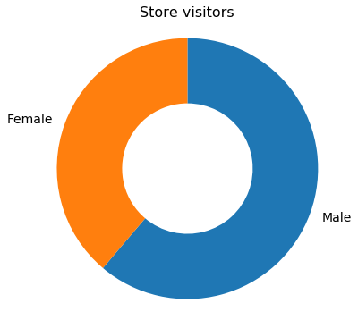

```python
plt.figure(figsize=[10,6])
df_sex = df_clean.groupby(['ID'])['Sex'].value_counts().reset_index(name = 'Sex_count')
df_sex['Sex'].value_counts().plot(kind = 'pie', startangle = 90, fontsize = 14, counterclock = False, wedgeprops = {'width' : 0.5})
plt.axis('square')
plt.xlabel('', fontsize = 14)
plt.ylabel('', fontsize = 14)
plt.title('Store visitors', fontsize = 16)
plt.show()
```

**ANSWER :** unexpected but there were mor men among the store visitors than a women

**QUESTION :** how does the income of the customers look like?

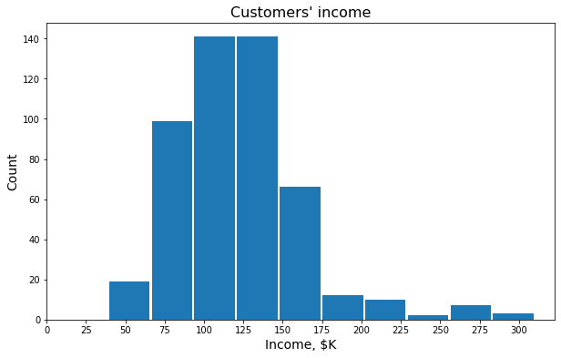

```python
plt.figure(figsize = [10,6])
xticks= range(0,325,25)
df_clean.groupby('ID')['Income'].mean().plot(kind = 'hist', rwidth = 0.95, xticks = xticks)
plt.xlabel('Income, $K', fontsize = 14)
plt.ylabel('Count', fontsize = 14)
plt.title("Customers' income" , fontsize = 16)
plt.show()
```

**ANSWER :** people with income between 75K and 175K visit the store more often

**QUESTION :** how old are the customers of sthe store?

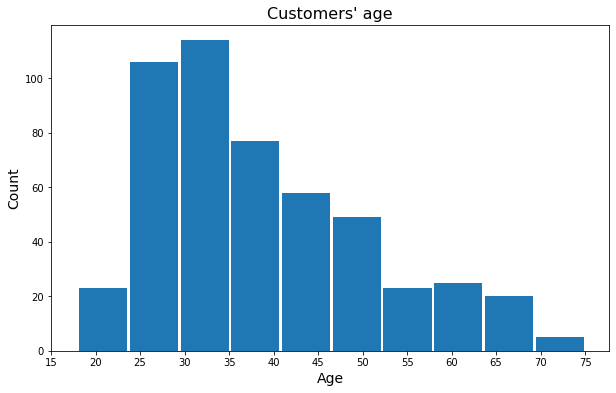

```python
plt.figure(figsize = [10,6])
xticks= range(15,80,5)
df_clean.groupby('ID')['Age'].mean().plot(kind = 'hist', rwidth = 0.95, xticks = xticks)
plt.xlabel('Age', fontsize = 14)
plt.ylabel('Count', fontsize = 14)
plt.title("Customers' age" , fontsize = 16)
plt.show()
```

**ANSWER :** the most visitors of the store are of age btw. 25 and 50

**QUESTION :** which size of the city the customers come from?

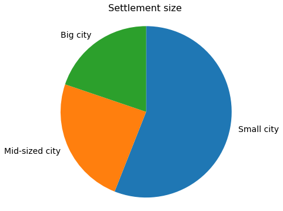

```python
plt.figure(figsize=[10,6])
df_settlement = df_clean.groupby(['ID'])['Settlement size'].value_counts().reset_index(name = 'Settlement size count')
df_settlement['Settlement size'].value_counts().plot(kind = 'pie', startangle = 90, fontsize = 14, counterclock = False)
plt.axis('square')
plt.xlabel('', fontsize = 14)
plt.ylabel('', fontsize = 14)
plt.title('Settlement size', fontsize = 16)
plt.show()
```

**ANSWER :** The majority of the customer come from the small city, then follwo the customers from mid-sized and eventually from the big city

**QUESTION :** what ist the further information about the customers regarding their occupation, education and marital status?

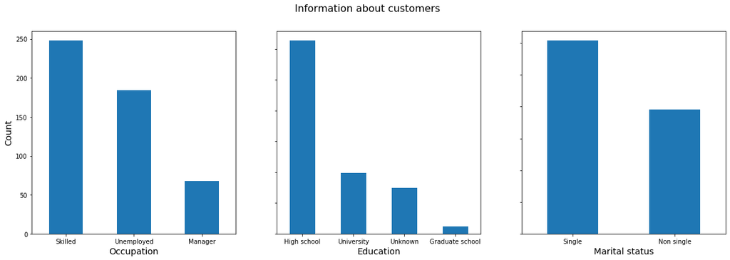

```python
fig, (ax1, ax2, ax3) = plt.subplots(1,3, figsize = [20,6])

plt.suptitle('Information about customers', fontsize = 16)

df_occup = df_clean.groupby(['ID'])['Occupation'].value_counts().reset_index(name = 'Occupation count')
df_occup['Occupation'].value_counts().plot(kind = 'bar', rot=0, ax=ax1)
ax1.set_xlabel('Occupation', fontsize = 14)
ax1.set_ylabel('Count', fontsize = 14)

df_sex = df_clean.groupby(['ID'])['Education'].value_counts().reset_index(name = 'Occupation count')
df_sex['Education'].value_counts().plot(kind = 'bar', rot=0, ax=ax2, sharey = True)
ax2.set_xlabel('Education', fontsize = 14)

df_sex = df_clean.groupby(['ID'])['Marital status'].value_counts().reset_index(name = 'Occupation count')
df_sex['Marital status'].value_counts().plot(kind = 'bar', rot=0, ax = ax3, sharey = True)
ax3.set_xlabel('Marital status', fontsize = 14)

plt.show()
```

**ANSWER :** the majority of customers are employeed singles with high scool education.

Next I will explore the purchases

**QUESTION :** how often do the customers purhased the item of interest?

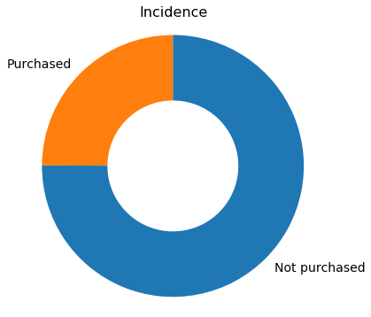

```python
plt.figure(figsize=[10,6])
df_clean['Incidence'].value_counts().plot(kind = 'pie', startangle = 90, fontsize = 14,
                                          counterclock = False, wedgeprops = {'width' : 0.5})
plt.axis('square')
plt.xlabel('', fontsize = 14)
plt.ylabel('', fontsize = 14)
plt.title('Incidence', fontsize = 16)
plt.show()
```

**ANSWER :** only in 25% of store visits the customer have purchased the item of interest

**QUESTION :** chocolate bars of which brand are the most popular?

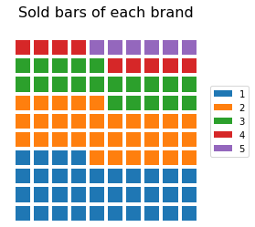

```python
def percentage_blocks(df, var):
    """
    Take as input a dataframe and variable, and return a Pandas series with
    approximate percentage values for filling out a waffle plot.
    """
    # compute base quotas
    percentages = 100 * df[var].value_counts() / df.shape[0]
    counts = np.floor(percentages).astype(int) # integer part = minimum quota
    decimal = (percentages - counts).sort_values(ascending = False)

    # add in additional counts to reach 100
    rem = 100 - counts.sum()
    for cat in decimal.index[:rem]:
        counts[cat] += 1

    return counts

new_df = df_clean[df_clean['Brand'] > 0]
new_df = new_df.reset_index(drop = True)

waffle_counts = percentage_blocks(new_df, 'Brand')
waffle_counts = waffle_counts.reset_index(drop = True)

prev_count = 0
# for each category,
for cat in range(waffle_counts.shape[0]):
    # get the block indices
    blocks = np.arange(prev_count, prev_count + waffle_counts[cat])
    # and put a block at each index's location
    x = blocks % 10 # use mod operation to get ones digit
    y = blocks // 10 # use floor division to get tens digit
    plt.bar(x = x, height = 0.8, width = 0.8, bottom = y)
    prev_count += waffle_counts[cat]

plt.title('Sold bars of each brand', fontsize = 16)
plt.legend(waffle_counts.index + 1, bbox_to_anchor = (1, 0.5), loc = 6)
plt.axis('off')
plt.axis('square');
```

**ANSWER :** the brands 1 and 2 are the most popular among the customers

**QUESTION :** how much chocolate bars do the customers buy the most?

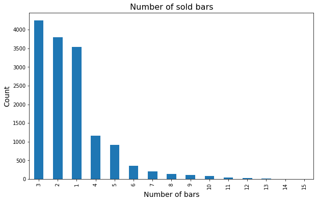

```python
plt.figure(figsize=[10,6])

df_clean['Quantity'].value_counts()[1:].plot(kind = 'bar')

plt.title('Number of sold bars', fontsize = 16)
plt.xlabel('Number of bars', fontsize = 14)
plt.ylabel('Count', fontsize = 14)

plt.show();
```

**ANSWER :** It's more likely thyt the customers buy 3, 2 or 1 item at once. Much rarer the customers buy 4 bars and more.

**QUESTION :** what can we say about promotions for each brand?

```python
prom_cols = ['Promotion_1', 'Promotion_2', 'Promotion_3', 'Promotion_4', 'Promotion_5']

prom_list = []

for prom in prom_cols:
    prom_list.append(df_clean[prom][df_clean[prom] == 'Promotion'].count())
```

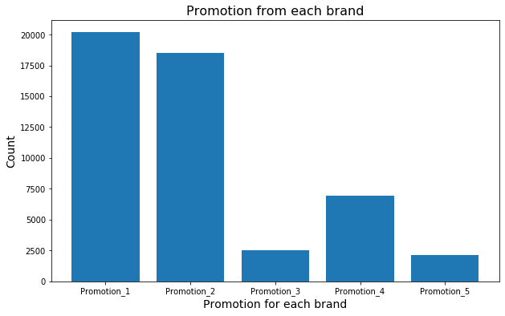

```python
plt.figure(figsize = [10,6])
plt.bar(prom_cols, prom_list)
plt.title('Promotion from each brand', fontsize = 16)
plt.ylabel('Count', fontsize = 14)
plt.xlabel('Promotion for each brand', fontsize = 14)
plt.show()
```

**ANSWER :** for the brands 1 and 2 there were the most promotions

**QUESTION :** does the promotions effect the number of sold bars from each brand?

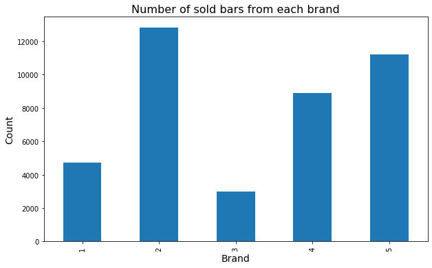

```python
plt.figure(figsize = [10,6])
df_clean.groupby('Brand')['Quantity'].sum()[1:].plot(kind = 'bar')
plt.title('Number of sold bars from each brand', fontsize = 16)
plt.ylabel('Count', fontsize = 14)
plt.xlabel('Brand', fontsize = 14)
plt.show()
```

**ANSWER :** interestingly there is no correlation between promotions and nubmer of sold bars. For instance, brand 1 made the most promotions but sold less bars than brand 4 and 5, although the number of promotions for these brands is much lower.

**SUMMARY :** by univariate exploration I have examined the main information about the customer, such as sex, age, income, occupation, education, marital status as well as the customers' purchase behavior regarding. By talking about unexpected findings, outliers or other inconsistent correlation in the data I was suprised to find out that men visit the store more often than women. Chocholate bars don't belong to the necessity goods and the customers buy them only in 25% of cases. Apart from that the data and looks pretty clean and logic. For instance it's more likely that customers buy 3 to 1 bar pro store visit.

## ${\textbf{Bivariate Exploration }}$

**QUESTION :** which brand of bars is mot expensive?

```python
price_cols = ['Price_1', 'Price_2', 'Price_3', 'Price_4', 'Price_5']

price_list = []

for price in price_cols:
    price_list.append(df_clean[price].mean())
```

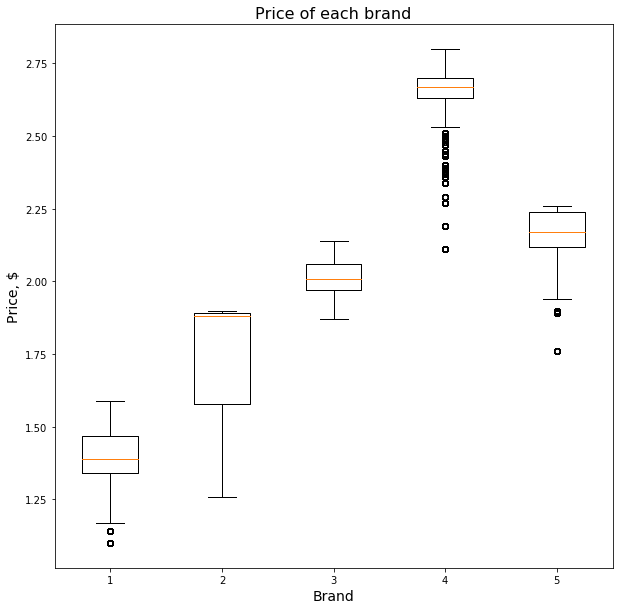

```python
plt.figure(figsize = [10,10])
x = [df_clean['Price_1'], df_clean['Price_2'], df_clean['Price_3'], df_clean['Price_5'], df_clean['Price_4']]
plt.boxplot(x)
plt.xlabel('Brand', fontsize = 14)
plt.ylabel('Price, $', fontsize = 14)
plt.title('Price of each brand', fontsize = 16)
plt.show()
```

**QUESTION :** how did the prices of the bars change over the time?

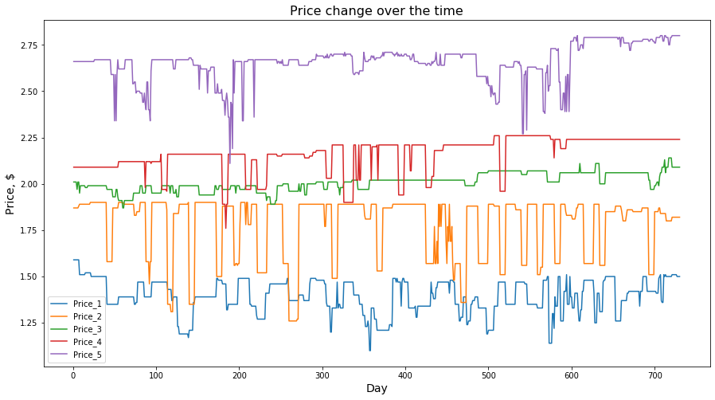

```python
price_cols = ['Price_1', 'Price_2', 'Price_3', 'Price_4', 'Price_5']

plt.figure(figsize=[15,8])

for price in price_cols:
    df_clean.groupby('Day')[price].mean().plot(label = price)


plt.title('Price change over the time', fontsize = 16)
plt.xlabel('Day', fontsize = 14)
plt.ylabel('Price, $', fontsize = 14)
plt.legend(loc='best')
plt.show()
```

**QUESTION :** is there some correlation between income of a custopmer and amount of money the customer spends on chocolate bars?

```python
df_outcome = df_clean.groupby(['ID', 'Brand'])['Quantity'].sum().reset_index(name = 'Count').pivot(index='ID', columns='Brand', values = 'Count')
```

```python
outcome_list = ['Outcome_1', 'Outcome_2', 'Outcome_3', 'Outcome_4', 'Outcome_5']
brand_list = range(1,6)
price_list = ['Price_1', 'Price_2', 'Price_3', 'Price_4', 'Price_5']


for outcome, brand, price in zip(outcome_list, brand_list, price_list):
    df_outcome[outcome] = df_outcome[brand] * df_clean[price].mean()
```

```python
df_outcome['Outcome_sum'] = df_outcome.loc[:, 'Outcome_1':'Outcome_5'].sum(axis=1)
```

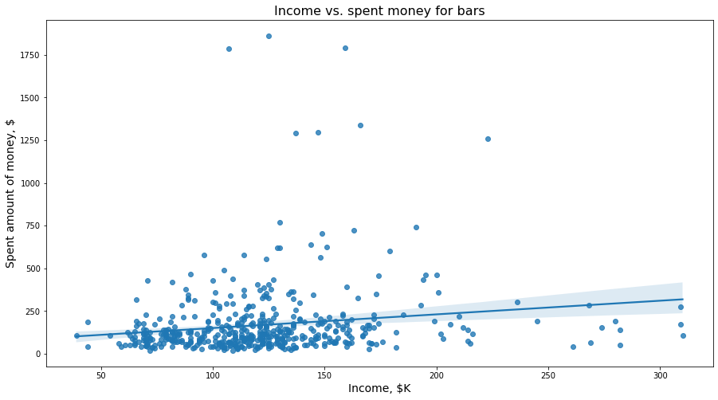

```python
plt.figure(figsize=[15,8])
sns.regplot(df_clean.groupby('ID')['Income'].mean(), df_outcome['Outcome_sum'])
plt.title('Income vs. spent money for bars', fontsize = 16)
plt.xlabel('Income, $K', fontsize = 14)
plt.ylabel('Spent amount of money, $', fontsize = 14)
plt.show()
```

**ANSWER :** it looks like there is no strong correlation between income of a customer with amount of money spent for chocolate bars. There are a couple of outliers above 1250$

**QUESTION :** is there some correlation between age an income of the customers and how does it look like?

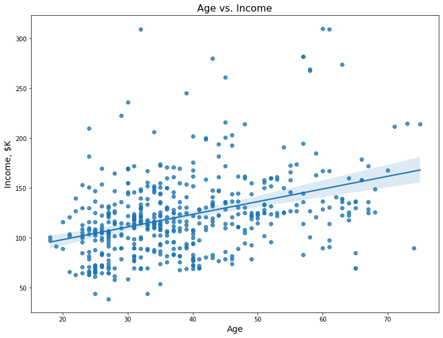

```python
plt.figure(figsize = (12, 9))
#plt.scatter(df_clean['Age'], df_clean['Income'])
sns.regplot(df_clean.groupby('ID')['Age'].mean(), df_clean.groupby('ID')['Income'].mean())
plt.xlabel('Age', fontsize = 14)
plt.ylabel('Income, $K', fontsize = 14)
plt.title('Age vs. Income', fontsize = 16)
plt.show()
```

**ANSWER :** there is indeed some correlation beteeen age and income. I will investigate this correlation depending on other different features by multivariate exploration

**SUMMARY :** by bivariate exploration i examined and compared the price of each brand, price development over the time, correlation between age and income of customers as well as how much money do the customers spent on chocolate bars depending on their income. By the prices of brand 1, 4 and 5 were determined some outliers. This outliers can be prices of the chocolate bars during correspondet promotions. Also there are some customers which spend much more moe´ney for bars compared to other customers. The majority of customers spent not more that 750\$ during observation time, but seven of them 1250\\$ and even more. But in generall i wouldn't say that the higher income means more bought bars. The correlation is almost the same between poeple with lower and hiher income. The correlation between age and income seems to be much stronger. Older customers earn more money but there are also outliers in each age group

## ${\textbf{Multivariate Exploration }}$

I will make a new DataFrame to explore the correlation between sex, marital status, age, education, income, occupation, settlement size

```python
df_segmentation = df_purchase[['ID', 'Sex','Marital status','Age','Education','Income', 'Occupation', 'Settlement size']].copy()
```

```python
df_segmentation = df_segmentation.set_index('ID')
```

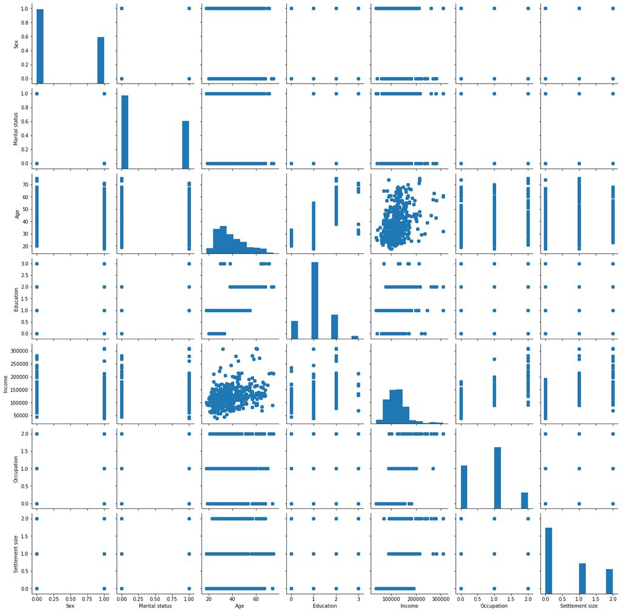

```python
g = sns.PairGrid(data = df_segmentation)
g.map_offdiag(plt.scatter)
g.map_diag(plt.hist)
plt.show()
```

Since a lot of features are categorical feautures, as expected there is a correlation between age and income.  
Let's take look at the pairwise correlations present between features using heatmap

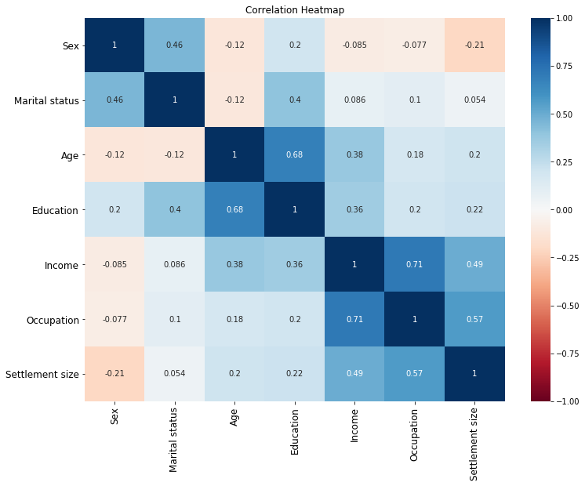

```python
plt.figure(figsize = (12, 9))
s = sns.heatmap(df_segmentation.corr(),
               annot = True,
               cmap = 'RdBu',
               vmin = -1,
               vmax = 1)
s.set_yticklabels(s.get_yticklabels(), rotation = 0, fontsize = 12)
s.set_xticklabels(s.get_xticklabels(), rotation = 90, fontsize = 12)
plt.title('Correlation Heatmap')
plt.show()
```

There are strong positive correlations between age and education, occupation and income, occupation and settlement size, income and settlement size.  
Let's take a closer look at age and income deoenden on sex, education, settlement size and ocupation

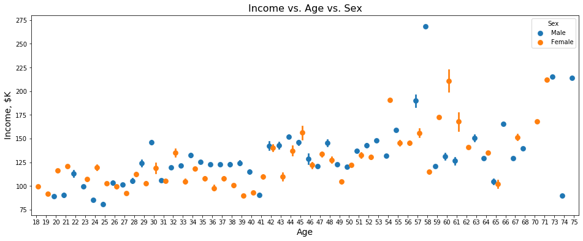

```python
fig = plt.figure(figsize = [16,6])
ax = sns.pointplot(data = df_clean, x = 'Age', y = 'Income', hue = 'Sex',
            linestyles = '', dodge = 0.4)
plt.xlabel('Age', fontsize = 14)
plt.ylabel('Income, $K', fontsize = 14)
plt.title('Income vs. Age vs. Sex', fontsize = 16)
plt.show()
```

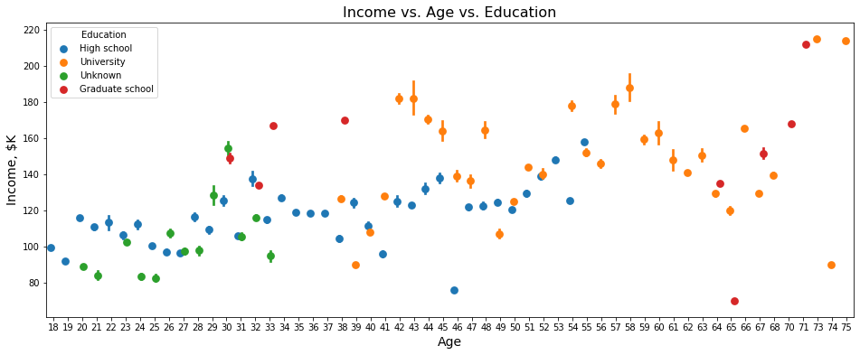

```python
fig = plt.figure(figsize = [16,6])
ax = sns.pointplot(data = df_clean, x = 'Age', y = 'Income', hue = 'Education',
            linestyles = '', dodge = 0.4)
plt.xlabel('Age', fontsize = 14)
plt.ylabel('Income, $K', fontsize = 14)
plt.title('Income vs. Age vs. Education', fontsize = 16)
plt.show()
```

Customers with univercity and high school education have higher income especially at the age of 40 and above

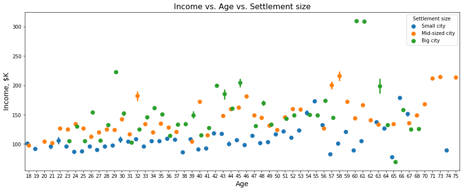

```python
fig = plt.figure(figsize = [16,6])
ax = sns.pointplot(data = df_clean, x = 'Age', y = 'Income', hue = 'Settlement size',
            linestyles = '', dodge = 0.4)
plt.xlabel('Age', fontsize = 14)
plt.ylabel('Income, $K', fontsize = 14)
plt.title('Income vs. Age vs. Settlement size', fontsize = 16)
plt.show()
```

The income od customers which come from big cities is also higher compared to mid-sized and small sities

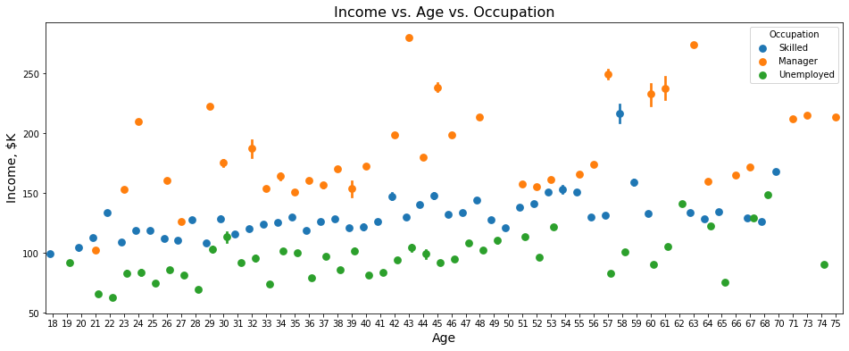

```python
fig = plt.figure(figsize = [16,6])
ax = sns.pointplot(data = df_clean, x = 'Age', y = 'Income', hue = 'Occupation',
            linestyles = '', dodge = 0.4)
plt.xlabel('Age', fontsize = 14)
plt.ylabel('Income, $K', fontsize = 14)
plt.title('Income vs. Age vs. Occupation', fontsize = 16)
plt.show()
```

As expected manager and employed customers have alsoe higher income compared to unemployed ones

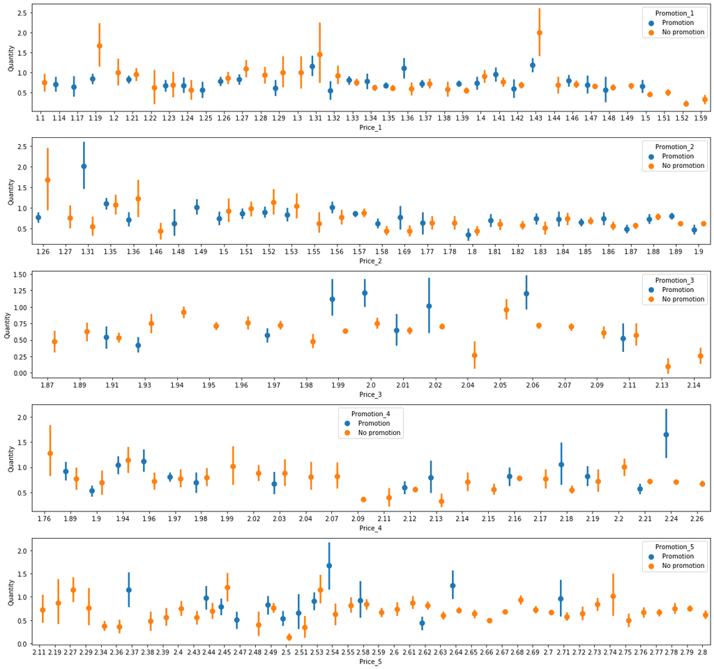

```python
fig, axes = plt.subplots(5,1, figsize = [16,15])

price_list = ['Price_1', 'Price_2', 'Price_3', 'Price_4', 'Price_5']
prom_list = ['Promotion_1', 'Promotion_2', 'Promotion_3', 'Promotion_4', 'Promotion_5']

for ax, price, prom in zip(axes.flatten(), price_list, prom_list):
    sns.pointplot(data = df_clean, x = price, y = 'Quantity', hue = prom,
            linestyles = '', dodge = 0.4, ax = ax, hue_order = ['Promotion', 'No promotion'])
plt.tight_layout()
plt.show()
```